# Damages Caused by US Storms

Nick Krabbenhoeft

February 22, 2015

# Synopsis

# Data Processing

```r
# packages to help analysis
library(reshape2)
library(dplyr)
library(plyr)
library(ggplot2)
library(scales)
```

From the National Weather Service (http://www.weather.gov/) we obtain the Storm Data publication (https://d396qusza40orc.cloudfront.net/repdata%2Fpeer2_doc%2Fpd01016005curr.pdf). Storm Data documents meterological events deemed significant because of damage caused (economic and loss of life), unusualness (summer snow in San Diego), or their connection to previous significant events. Our copy of Storm Data is hosted by the John’s Hopkins Reproducible Research Coursera Course.

## Reading in the data

```r
# download file to a temporary data directory
if (!file.exists('../../../data/StormData.csv.bz2')) {
        download.file('https://d396qusza40orc.cloudfront.net/repdata%2Fdata%2FStormData.csv.bz2',
                      destfile = '../../../data/StormData.csv.bz2',
                      method = 'curl')
        }


storms <- read.csv(bzfile('../../../data/StormData.csv.bz2'), na.strings = "", comment.char = "", nrows = 1000000)
# select subset of dataset relating to health and economy
storms <- select(storms, EVTYPE, FATALITIES, INJURIES, PROPDMG, PROPDMGEXP, CROPDMG, CROPDMGEXP)

head(storms)
```

```
##    EVTYPE FATALITIES INJURIES PROPDMG PROPDMGEXP CROPDMG CROPDMGEXP
## 1 TORNADO          0       15    25.0          K       0       <NA>
## 2 TORNADO          0        0     2.5          K       0       <NA>
## 3 TORNADO          0        2    25.0          K       0       <NA>
## 4 TORNADO          0        2     2.5          K       0       <NA>
## 5 TORNADO          0        2     2.5          K       0       <NA>
## 6 TORNADO          0        6     2.5          K       0       <NA>
```

There are 7 columns and 902297 rows is the dataset. In order to see a high level aggregation of the data, we group together types of events.

```r
storms$EVTYPE <- tolower(as.character(storms$EVTYPE))
storms$EVTYPE[grep('waterspout', storms$EVTYPE)] <- 'waterspout'
storms$EVTYPE[grep('tstm wind', storms$EVTYPE)] <- 'tstm wind'
storms$EVTYPE[grep('tornad|funnel', storms$EVTYPE)] <- 'tornado'
storms$EVTYPE[grep('thunder', storms$EVTYPE)] <- 'thunderstorm'
storms$EVTYPE[grep('snow|blizzard', storms$EVTYPE)] <- 'snow'
storms$EVTYPE[grep('lightn', storms$EVTYPE)] <- 'lightning'
storms$EVTYPE[grep('ice|hail|frost', storms$EVTYPE)] <- 'ice'
storms$EVTYPE[grep('flood|fld', storms$EVTYPE)] <- 'flooding'
storms$EVTYPE[grep('cold|wint|freez|sleet', storms$EVTYPE)] <- 'cold'
storms$EVTYPE[grep('dry micr', storms$EVTYPE)] <- 'dry microburst'
storms$EVTYPE[grep('excessive|extreme|record|unseasonably', storms$EVTYPE)] <- 'extreme'
storms$EVTYPE[grep('heavy (mix|rain|pre)', storms$EVTYPE)] <- 'heavy rain'
storms$EVTYPE[grep('hurricane', storms$EVTYPE)] <- 'hurricane'
storms$EVTYPE[grep('summary', storms$EVTYPE)] <- 'summary'
storms$EVTYPE[grep('fire', storms$EVTYPE)] <- 'fire'
storms$EVTYPE[grep('wind', storms$EVTYPE)] <- 'wind'

storms$EVTYPE[grep('surf|surge|tsunami|current|sea', storms$EVTYPE)] <- 'high wind'
storms$EVTYPE<-factor(storms$EVTYPE)
```

Economic estimates of property and crop damage are encoded with exponents. We convert these to natural numbers.

```r
# convert text labels to exponents
storms$PROPDMGEXP <- revalue(storms$PROPDMGEXP,
                          c('?' = 0, '+' = 0, '-' = 0, 'H' = 2, 'h' = 2,
                            'K' = 3, 'k' = 3, 'm' = 6, 'M' = 6, 'B' = 9))
storms$CROPDMGEXP <- revalue(storms$CROPDMGEXP,
                          c('?' = 0, '+' = 0, '-' = 0, 'H' = 2, 'h' = 2,
                            'K' = 3, 'k' = 3, 'm' = 6, 'M' = 6, 'B' = 9))

# multiply damage ammounts by their exponents to obtain full dollar estimates
storms$PROPDMGNUM <- as.numeric(storms$PROPDMG) * 10^as.numeric(storms$PROPDMGEXP)
storms$CROPDMGNUM <- as.numeric(storms$CROPDMG) * 10^as.numeric(storms$CROPDMGEXP)
```

Brief summaries of health and economic variables.

```r
summary(storms$FATALITIES)
```

```
##     Min.  1st Qu.   Median     Mean  3rd Qu.     Max.
##   0.0000   0.0000   0.0000   0.0168   0.0000 583.0000
```

```r
summary(storms$INJURIES)
```

```
##      Min.   1st Qu.    Median      Mean   3rd Qu.      Max.
##    0.0000    0.0000    0.0000    0.1557    0.0000 1700.0000
```

```r
summary(storms$PROPDMGNUM)
```

```
##      Min.   1st Qu.    Median      Mean   3rd Qu.      Max.      NA's
## 0.000e+00 0.000e+00 1.000e+04 9.814e+06 1.000e+05 1.150e+12    465934
```

```r
summary(storms$CROPDMGNUM)
```

```
##     Min.  1st Qu.   Median     Mean  3rd Qu.     Max.     NA's
##        0        0        0    59350        0 59600000   618413
```

Property and crop damage is unreported for over half of events. NWS is only required by law to report damage related to floods.

Finally, we aggregate all data by event type, adding together the damage estimates and counting the number of events. We also filter out events that have less than 10 occurences in order to focus on more frequent events and calculate the average impact per event. Because some events have mandatory reporting, such as floods, and others do not. The average is the best measure to understand the impact per event type.

```r
storms.agg <- ddply(storms, .(EVTYPE), summarize,
                    total = length(EVTYPE),
                    injury = sum(INJURIES, na.rm = T),
                    fatality = sum(FATALITIES, na.rm = T),
                    propdmg = sum(PROPDMGNUM, na.rm = T),
                    cropdmg = sum(CROPDMGNUM, na.rm = T))

storms.agg <- storms.agg %>%
        # filter low occurence events
        filter(total > 10) %>%
        # find average impact per event
        mutate(healthavg = (injury+fatality)/total,
               econavg = (propdmg +cropdmg)/total)
head(storms.agg)
```

```
##                   EVTYPE total injury fatality     propdmg    cropdmg
## 1 astronomical high tide   103      0        0    94250000          0
## 2  astronomical low tide   174      0        0     3200000          0
## 3              avalanche   386    170      224    37218000          0
## 4                   cold 22676   2326      728 70410166510  312675200
## 5              dense fog  1293    342       18    96740000          0
## 6                drought  2488      4        0 10461060000 1459573500
##     healthavg    econavg
## 1 0.000000000  915048.54
## 2 0.000000000   18390.80
## 3 1.020725389   96419.69
## 4 0.134679838 3118841.14
## 5 0.278422274   74818.25
## 6 0.001607717 4791251.41
```

# Results

## Across the United States, which types of events are most harmful with respect to population health?

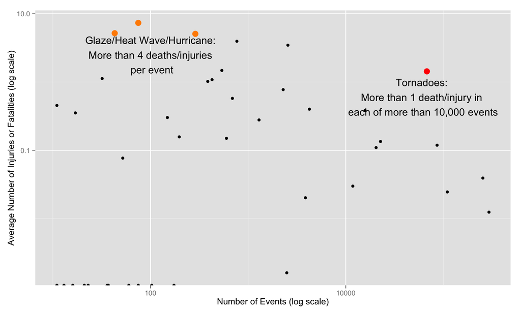

```r
ggplot(storms.agg) +
        geom_point(aes(total, healthavg)) +
        geom_point(data = filter(storms.agg, healthavg > 4),
                   aes(total, healthavg), col = 'dark orange', size = 4) +
        geom_point(data = filter(storms.agg, healthavg > 1, total > 10000),
                   aes(total, healthavg), col = 'red', size = 4) +
        scale_x_log10() + scale_y_log10() +
        labs(x = 'Number of Events (log scale)',
             y = 'Average Number of Injuries or Fatalities (log scale)') +
        annotate('text', x = 100, y = 2.5,
                 label = 'Glaze/Heat Wave/Hurricane:\nMore than 4 deaths/injuries\n per event') +
        annotate('text', x = 60000, y = .6,
                 label = 'Tornadoes:\nMore than 1 death/injury in\n each of more than 10,000 events')
```

```r
filter(storms.agg, healthavg > 4)
```

```
##      EVTYPE total injury fatality      propdmg   cropdmg healthavg
## 1     glaze    43    216        7     10000000         0  5.186047
## 2 heat wave    75    379      172    104600500   3030000  7.346667
## 3 hurricane   288   1328      135 847561800100 467977510  5.079861
##        econavg
## 1     232558.1
## 2    1435073.3
## 3 2944547838.9
```

```r
filter(storms.agg, healthavg > 1, total > 10000)
```

```
##    EVTYPE total injury fatality      propdmg    cropdmg healthavg econavg
## 1 tornado 67675  91367     5633 569523515235 1027056200  1.433321 8430744
```

## Across the United States, which types of events have the greatest economic consequences?

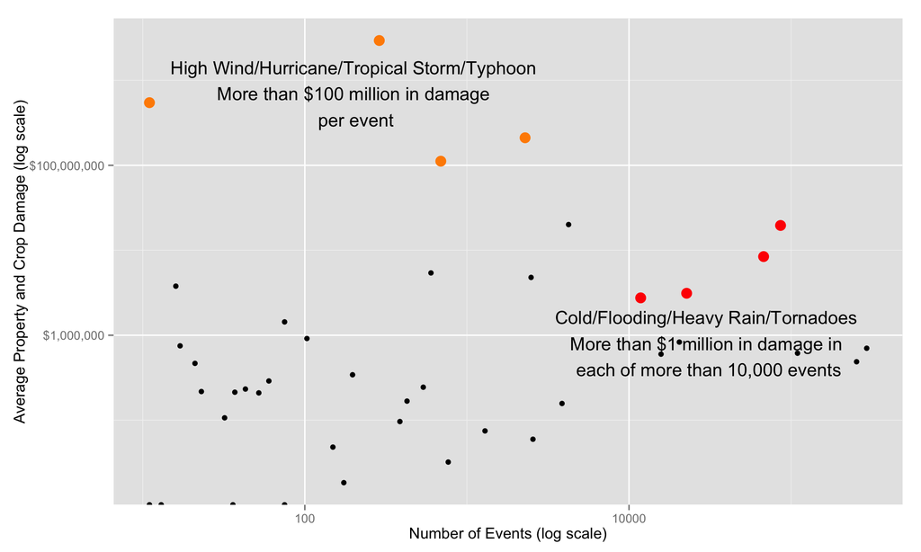

```r
ggplot(storms.agg) +
        geom_point(aes(total, econavg)) +
        geom_point(data = filter(storms.agg, econavg > 100000000),
                   aes(total, econavg), col = 'dark orange', size = 4) +
        geom_point(data = filter(storms.agg, econavg > 1000000, total > 10000),
                   aes(total, econavg), col = 'red', size = 4) +
        scale_x_log10() + scale_y_log10(label = dollar) +
        labs(x = 'Number of Events (log scale)',
             y = 'Average Property and Crop Damage (log scale)') +
        annotate('text', x = 200, y = 700000000,
                 label = 'High Wind/Hurricane/Tropical Storm/Typhoon\nMore than $100 million in damage\n per event') +
        annotate('text', x = 30000, y = 800000,
                 label = 'Cold/Flooding/Heavy Rain/Tornadoes\nMore than $1 million in damage in\n each of more than 10,000 events')
```

The graph above compares the property and crop damage against the number of events. Because of the extreme scales of the data, both are charted on a log scale. The group of orange points highlights the events with the greatest economic impact per event: high wind, hurricane, tropical storm, typhoon. The group of red point highlights the most freqent events which average more than $1,000,000 in damages.

```r
filter(storms.agg, econavg > 100000000)
```

```
##           EVTYPE total injury fatality      propdmg   cropdmg healthavg
## 1      high wind  2285    960      808 482109395000   9750000 0.7737418
## 2      hurricane   288   1328      135 847561800100 467977510 5.0798611
## 3 tropical storm   690    340       58  77038905500 119572000 0.5768116
## 4        typhoon    11      5        0   6002300000   8250000 0.4545455
##      econavg
## 1  210993061
## 2 2944547839
## 3  111823880
## 4  546413636
```

```r
filter(storms.agg, econavg > 1000000, total > 10000)
```

```
##       EVTYPE total injury fatality      propdmg    cropdmg  healthavg
## 1       cold 22676   2326      728 7.041017e+10  312675200 0.13467984
## 2   flooding 86102   8681     1553 1.682577e+12 4304510000 0.11885903
## 3 heavy rain 11802    255       98 3.229348e+10  187548000 0.02991018
## 4    tornado 67675  91367     5633 5.695235e+11 1027056200 1.43332102
##    econavg
## 1  3118841
## 2 19591663
## 3  2752163
## 4  8430744
```

# Conclusions

These two types of events require different strategies to mitigate their effects. The freqency and geographic spread of tornadoes should be addressed with widespread funding for distributed emergency services, hurricane preparation can be more regionally concentrated.